# R Notebook

# Visualising Y haplogroup frequencies and CNE admixture proportions

Read in data from two tables. One giving all the Y haplogroups of the male samples, and one giving the autosomal CNE admixture estimate per individual (Email to David on Sep 29).

```r
dat1 <- readxl::read_excel("data/ForFrequencies_Stephan.xlsx", range = readxl::cell_cols("A:D")) %>%
  dplyr::mutate(
    Haplogroup = ifelse(stringr::str_starts(Haplogroup, "I2"), "I2", Haplogroup)
  )
# cne_admix_rates <- readxl::read_excel("data/CNE_WBI.xlsx")
cne_admix_rates <- readxl::read_excel("data/SexBias_Table_forDavid.xlsx") %>%
  dplyr::rename(aCNE = `aCNE autosomes`) %>%
  dplyr::select(Individual, aCNE) %>%
  dplyr::rename(CNE = aCNE, Ind = Individual)

sites_tab <- readxl::read_excel("data/Haplogroups_CNE.xlsx") %>%
  dplyr::select(ID, Locality, Sex)
```

We can easily join the two:

```r
datj <- dat1 %>%
  dplyr::left_join(cne_admix_rates, by=c("ID" = "Ind")) %>%
  dplyr::left_join(sites_tab, by="ID")
```

Here are the numbers per group:

```r
datj %>% dplyr::group_by(Population) %>% dplyr::summarise(n = dplyr::n())
```

| Population | n |
| --- | --- |
| Britain_PreEMA | 14 |
| England_EMA | 105 |
| England_PreEMA | 50 |
| Ireland_EMA | 28 |
| NorthSea_EMA | 128 |
| Scandianvia_EMA | 112 |

We now declare three groups of samples. First, a group of admixed individuals from England_EMA:

```r
admixed_inds <- datj %>% dplyr::filter(CNE > 0.02 & CNE < 0.98)
```

and then two source groups:

```r
source1_inds <- datj %>%
  dplyr::filter(Population %in% c("Britain_PreEMA", "England_PreEMA") | CNE < 0.02)
source2_inds <- datj %>% dplyr::filter(CNE > 0.98 | Population == "NorthSea_EMA")
```

We can now get the haplogroup frequencies in the two sources:

```r
source1_haps <- source1_inds %>% dplyr::group_by(Haplogroup) %>% dplyr::summarise(n1 = dplyr::n())
N1 <- sum(source1_haps$n1)
source2_haps <- source2_inds %>% dplyr::group_by(Haplogroup) %>% dplyr::summarise(n2 = dplyr::n())
N2 <- sum(source2_haps$n2)
source_haps <- dplyr::full_join(source1_haps, source2_haps, by="Haplogroup") %>%
  tidyr::replace_na(list(n1 = 0, n2 = 0)) %>%
  dplyr::mutate(x1 = n1 / N1,
                x2 = n2 / N2,
                x1p = (n1 + 1) / (N1 + 1),
                x2p = (n2 + 1) / (N2 + 1),
                post_prob2 = x2p / (x1p + x2p))
source_haps
```

| Haplogroup | n1 | n2 | x1 | x2 | x1p | x2p | post_prob2 |
| --- | --- | --- | --- | --- | --- | --- | --- |
| I1 | 1 | 58 | 0.01449275 | 0.320441989 | 0.02857143 | 0.32417582 | 0.9190031 |
| I2 | 4 | 15 | 0.05797101 | 0.082872928 | 0.07142857 | 0.08791209 | 0.5517241 |
| J | 1 | 4 | 0.01449275 | 0.022099448 | 0.02857143 | 0.02747253 | 0.4901961 |
| R-P312 | 53 | 27 | 0.76811594 | 0.149171271 | 0.77142857 | 0.15384615 | 0.1662708 |
| R-U106 | 2 | 41 | 0.02898551 | 0.226519337 | 0.04285714 | 0.23076923 | 0.8433735 |
| R1b | 8 | 12 | 0.11594203 | 0.066298343 | 0.12857143 | 0.07142857 | 0.3571429 |
| E | 0 | 4 | 0.00000000 | 0.022099448 | 0.01428571 | 0.02747253 | 0.6578947 |
| G | 0 | 5 | 0.00000000 | 0.027624309 | 0.01428571 | 0.03296703 | 0.6976744 |
| I | 0 | 3 | 0.00000000 | 0.016574586 | 0.01428571 | 0.02197802 | 0.6060606 |
| NO1 | 0 | 1 | 0.00000000 | 0.005524862 | 0.01428571 | 0.01098901 | 0.4347826 |

[output cut: 2 more lines]

where the last column `post_prob2` gives a rough estimate for the probability of a haplogroup to come from source2. We can join this table with the admixed individuals:

```r
admixed_inds_j <- admixed_inds %>% dplyr::left_join(source_haps, by="Haplogroup") %>% tidyr::drop_na()
admixed_inds_j
```

| ID | Population | Region | Haplogroup | CNE | Locality | Sex | n1 | n2 | x1 | x2 | x1p | x2p | post_prob2 |
| --- | --- | --- | --- | --- | --- | --- | --- | --- | --- | --- | --- | --- | --- |
| I20639 | England_EMA | England | I1 | 0.696761 | West Heslerton | M | 1 | 58 | 0.01449275 | 0.32044199 | 0.02857143 | 0.32417582 | 0.9190031 |
| HAD003 | England_EMA | England | I1 | 0.447964 | Hatherdene | M | 1 | 58 | 0.01449275 | 0.32044199 | 0.02857143 | 0.32417582 | 0.9190031 |
| OAI008 | England_EMA | England | I1 | 0.677121 | Oakington | M | 1 | 58 | 0.01449275 | 0.32044199 | 0.02857143 | 0.32417582 | 0.9190031 |
| I20645 | England_EMA | England | I1 | 0.364706 | West Heslerton | M | 1 | 58 | 0.01449275 | 0.32044199 | 0.02857143 | 0.32417582 | 0.9190031 |
| I16508 | England_EMA | England | I1 | 0.510438 | Wolverton | M | 1 | 58 | 0.01449275 | 0.32044199 | 0.02857143 | 0.32417582 | 0.9190031 |
| I16383 | England_EMA | England | I1 | 0.548583 | Bude, Widemouth Bay | M | 1 | 58 | 0.01449275 | 0.32044199 | 0.02857143 | 0.32417582 | 0.9190031 |
| SED014 | England_EMA | England | I1 | 0.854718 | Sedgeford | M | 1 | 58 | 0.01449275 | 0.32044199 | 0.02857143 | 0.32417582 | 0.9190031 |
| I0790 | England_EMA | England | I1 | 0.270858 | Linton | M | 1 | 58 | 0.01449275 | 0.32044199 | 0.02857143 | 0.32417582 | 0.9190031 |
| LAK006 | England_EMA | England | I2 | 0.885980 | Lakenheath | M | 4 | 15 | 0.05797101 | 0.08287293 | 0.07142857 | 0.08791209 | 0.5517241 |
| POH006 | England_EMA | England | R1a | 0.562793 | Polhill | M | 0 | 10 | 0.00000000 | 0.05524862 | 0.01428571 | 0.06043956 | 0.8088235 |

[output cut: 32 more lines]

We can now plot each individua’s autosomal CNE admixture estimate together with estimate of his haplogroup coming from source 2:

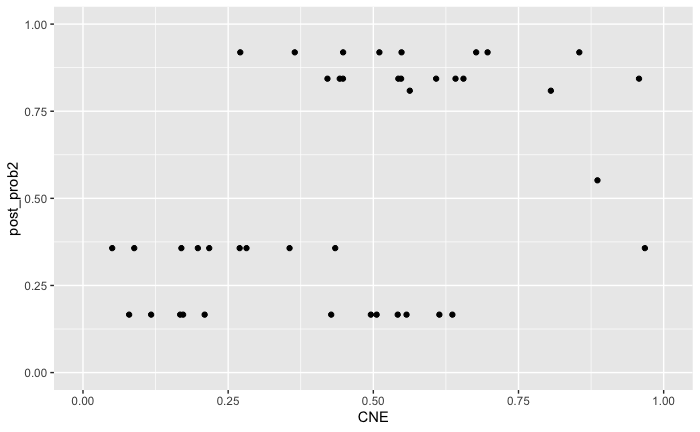

```r
admixed_inds_j %>%
  ggplot() + geom_point(aes(CNE, post_prob2)) +
  xlim(0, 1) + ylim(0, 1)
```

Here is a first and quick interpretation: Admixed individuals tend to carry Y chromosome haplogroups that have an overprortionally higher chance to come from the CNE group, indicating some amount of sex-bias to me.

Can we make this more statistically sound?

# Modelling Sex-bias

We set up a model with two parameters:

The first parameter, $\alpha$, determines the amount of CNE ancestry in his or her family tree. The second parameter, $\beta$ determines the proportion of males in the CNE pool, with $1-\beta$ being the proportion of males in the local (WBI-related) group.

This leads to a simple calculation of male immigrant ancestry over total male ancestry, $\gamma$:

$$\gamma(\alpha, \beta) = \frac{\beta \alpha}{\beta \alpha + (1 - \beta) (1 - \alpha)}$$

```r
male_adm_prop <- function(alpha, beta) {
  beta * alpha / (beta * alpha + (1 - beta) * (1 - alpha))
}
```

We can visualise this model as follows:

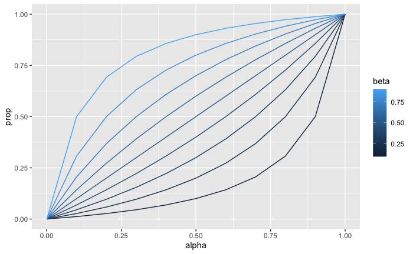

```r
tidyr::expand_grid(alpha = seq(0, 1, 0.1), beta = seq(0.1, 0.9, 0.1)) %>%
  dplyr::mutate(prop = male_adm_prop(alpha, beta)) %>%
  ggplot() +
    geom_line(aes(alpha, prop, col=beta, group = beta)) +
    xlim(c(0, 1)) + ylim(c(0, 1))
```

which shows that values of $\beta$ different from 0.5 can increase or decrease the male admixture proportion and deviate the curve from a model without sex-bias (a straight line).

In order to estimate $\beta$ from the data, we need to have an likelihood model. The core component is the probability to draw a specific Y chromosome haplotype given the known CNE proportion $\alpha$ and a given $\beta$ proportion, as well as the number of times $n_1$ and $n_2$ that haplogroup is seen in the two source groups, and the total number of haplogroups I know in the source groups, $N_1$ and $N_2$:

$$p(\text{Y-hap}|\alpha, \beta, n_1, N_1, n_2, N_2)$$

## A simple binomial model

A simple approach would simply be a single random draw with probability $x_2=n_2/N_2$ with probability $\gamma$ and $x_1 = n_1 / N_1$ with probability $1-\gamma$:

$$p(\text{Y-hap}|\alpha, \beta, n_1, N_1, n_2, N_2) = \gamma(\alpha, \beta) \frac{n_2 + 1}{N_2 + 1} + (1 - \gamma(\alpha, \beta)) \frac{n_1 + 1}{N_1 + 1}$$

where, in order to avoid zero probabilities for haplogroups that we have not seen in a source, we have added a pseudo-count of 1 for each observed haplogroup.

```r
bin_likelihood_part <- function(alpha, beta, n1, N1, n2, N2) {
  male_adm_prop(alpha, beta) * (n2 + 1) / (N2 + 1) + (1 - male_adm_prop(alpha, beta)) * (n1 + 1) / (N1 + 1)
}
```

We can now compute the log-likelihood as a sum over all male admixed individuals

```r
bin_log_likelihood <- function(data, beta, N1, N2) {
  sum(log(bin_likelihood_part(data$CNE, beta, data$n1, N1, data$n2, N2)))
}
```

We can now compute a log likelihood of the data given various values of beta:

```r
tibble::tibble(beta = seq(0.1, 0.9, 0.1)) %>%
  dplyr::mutate(log_l = purrr::map_dbl(beta, ~ bin_log_likelihood(admixed_inds_j, .x, N1, N2)))
```

| beta | log_l |
| --- | --- |
| 0.1 | -80.16725 |
| 0.2 | -75.27501 |
| 0.3 | -72.26672 |
| 0.4 | -70.31175 |
| 0.5 | -69.09834 |
| 0.6 | -68.51081 |
| 0.7 | -68.56072 |
| 0.8 | -69.42243 |
| 0.9 | -71.69566 |

```r
optimize(function(beta) bin_log_likelihood(admixed_inds_j, beta, N1, N2), c(0.01, 0.99), maximum = TRUE)
```

```
$maximum
[1] 0.6435681

$objective
[1] -68.44882
```

So 0.64 indeed. We can plot that model together with our frequency-based estimates:

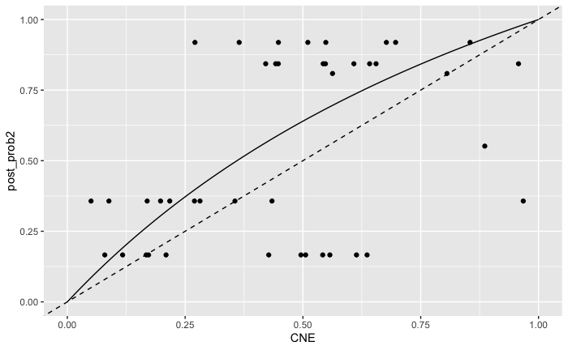

```r
model_plot_dat <- tibble::tibble(alpha=seq(0, 1, 0.01)) %>% dplyr::mutate(male_prop = male_adm_prop(alpha, 0.64))
admixed_inds_j %>%
  ggplot() + geom_point(aes(CNE, post_prob2)) +
    geom_line(data = model_plot_dat, aes(x = alpha, y = male_prop)) +
    geom_abline(slope = 1, linetype="dashed") + xlim(0, 1) + ylim(0, 1)
```

We can visualise a posterior distribution by grid-computing across beta:

```r
ll_grid <- tibble::tibble(beta = seq(0.01, 0.99, 0.01)) %>%
  dplyr::mutate(log_l = purrr::map_dbl(beta, ~ bin_log_likelihood(admixed_inds_j, .x, N1, N2)))
```

Let’s get the maximum:

```r
m <- max(ll_grid$log_l)
m
```

```
[1] -68.44924
```

```r
ll_grid_scaled <- ll_grid$log_l - m
norm <- sum(exp(ll_grid_scaled))
ll_grid_norm <- ll_grid %>% dplyr::mutate(post = exp(log_l - m) / norm)
ll_grid_norm
```

| beta | log_l | post |
| --- | --- | --- |
| 0.01 | -89.29455 | 2.997851e-11 |
| 0.02 | -87.65111 | 1.550763e-10 |
| 0.03 | -86.30163 | 5.978817e-10 |
| 0.04 | -85.13799 | 1.914165e-09 |
| 0.05 | -84.10751 | 5.364292e-09 |
| 0.06 | -83.17941 | 1.356999e-08 |
| 0.07 | -82.33365 | 3.161458e-08 |
| 0.08 | -81.55620 | 6.879112e-08 |
| 0.09 | -80.83670 | 1.412558e-07 |
| 0.10 | -80.16725 | 2.758960e-07 |

[output cut: 89 more lines]

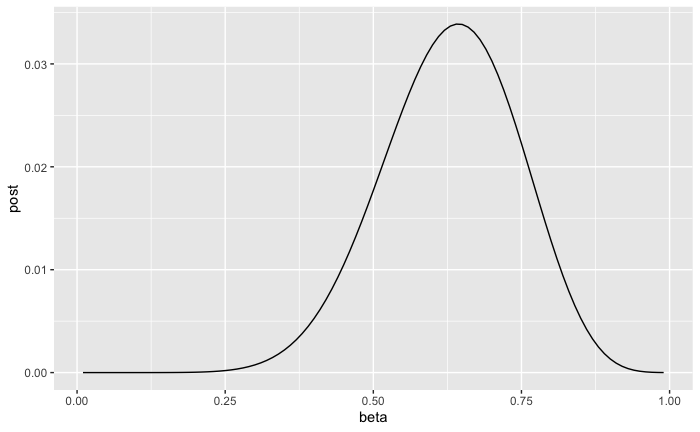

```r
ggplot(ll_grid_norm) + geom_line(aes(beta, post))
```

# Exploring different estimates for the admixture proportion